# ECo 602 - Analysis of Environmental Data

Final Project

Roberto Navarrete Arias

Fall 2020

# Introduction

This Final Project will contain two parts.

In the first one, I will explain, in simple words and using examples, some of the most important R functions that we have learned in this course.

In the second part, I will perform a data analysis for a given data set in order to decide which model would be a better fit for it.

To produce this, all the knowledge obtained in this course has been used.

# Functions 1: Data Structure Functions

## `c()`

The function `c()` *combines* or *concatenates* its arguments into a vector (a 1-dimensional data structure consisting of 1 or more elements).

- All of the elements must be of the same *type*.
- I can’t combine character and numeric types in the same call to `c()`

Here’s two examples using numeric and character data types:

```r
# Create a vector of numbers:
num_vec  = c(1, 4, 8, 9, 13)

# Create a vector of characters:
char_vec = c("a", "fish", "data is cool")
```

#I can show the contents of a vector by typing the name of the vector, or using the `print()` function.

```r
# Typing the name of the vector into the console prints the contents
num_vec
```

```
## [1]  1  4  8  9 13
```

```r
# The print() function accomplishes the same task:
print(char_vec)
```

```
## [1] "a"            "fish"         "data is cool"
```

## `data.frame()`

The function `data.frame()` *combines* or *concatenates* its vectorized arguments into a data frame (a 2-dimensional data structure consisting of at least 2 elements).

- The elements can be of the same or of a different *type (numerical, character, logical)*.

Here’s two examples using numeric and character data types:

```r
# Type your data frame example here. In the arguments, we write the vectors that will be part of this data frame. For this case, the first vector will be of character type and the second vector of numerical type.

dat_1 = data.frame(letters = c("b", "w", "B"),
           numbers_1 = c(34, 6, 123454))

# I can print the contents by typing the names of the data frame

dat_1
```

```
##   letters numbers_1
## 1       b        34
## 2       w         6
## 3       B    123454
```

```r
# Subset a column by name

dat_1$letters
```

```
## [1] "b" "w" "B"
```

```r
# Subset a column by place.

## I should leave the first space blank because it refers to rows and only fill the second space, that refers to columns. Since I am writing the number "2", I will be getting the second column.

dat_1[,2]
```

```
## [1]     34      6 123454
```

```r
# Subset a row by place.

## I should leave the second space blank because it refers to columns and only fill the first space, that refers to rows. Since I am writing the number "3", I will be getting the third row.

dat_1[3,]
```

```
##   letters numbers_1
## 3       B    123454
```

```r
# Subset an element by place.

## In the first space, I should write the row where the element is located and in the second space, the column where the element is located. Since I want to get the element "123454", I will be writing "3" for row and "2" for column.

dat_1[3,2]
```

```
## [1] 123454
```

## `matrix()`

The function `matrix()` *combines* or *concatenates* its vectorized arguments into a matrix (a 2-dimensional data structure consisting of at least 2 elements).

- All of the elements must be of the same *type*..

Here’s two examples using numeric and character data types:

```r
# Type your matrix example here. In the first argument, we write the elements of the matrix. In this case, the matrix will be of numerical type with numbers from 1 to 21. In the second argument, we put the number of rows that the matrix will have and in the third argument, the number of columns.

mat_1 = matrix(1:21,
               nrow = 3,
               ncol = 7)


# I can print the contents by typing the names of the matrix

mat_1
```

```
##      [,1] [,2] [,3] [,4] [,5] [,6] [,7]
## [1,]    1    4    7   10   13   16   19
## [2,]    2    5    8   11   14   17   20
## [3,]    3    6    9   12   15   18   21
```

```r
# The matrix is filled by column by default. If we want to fill it by row, we can add the byrow argument with a logical value of TRUE.

mat_2 = matrix(1:21, nrow = 3,
               ncol = 7,
               byrow = TRUE)

mat_2
```

```
##      [,1] [,2] [,3] [,4] [,5] [,6] [,7]
## [1,]    1    2    3    4    5    6    7
## [2,]    8    9   10   11   12   13   14
## [3,]   15   16   17   18   19   20   21
```

## `length()`

Function “length” is used to get the number of elements of vectors

```r
length(num_vec)
```

```
## [1] 5
```

```r
# It does not matter if the elements of the vector are not numerical

length(char_vec)
```

```
## [1] 3
```

```r
# It can also be used for other R objects, such as matrix

length(mat_2)
```

```
## [1] 21
```

## `nrow()`

Function “nrow” returns the number of rows present in an R object, like a matrix or a data frame

```r
nrow(mat_1)
```

```
## [1] 3
```

```r
nrow(dat_1)
```

```
## [1] 3
```

## `ncol()`

Function “ncol” returns the number of columns present in an R object, like a matrix or a data frame

```r
ncol(mat_1)
```

```
## [1] 7
```

```r
ncol(dat_1)
```

```
## [1] 2
```

## `dim()`

Function “dim” retrieves the dimensions of an R object, like a matrix or a data frame. The first element shown will be the number of rows and the second element shown will be the number of columns

```r
dim(mat_1)
```

```
## [1] 3 7
```

```r
dim(dat_1)
```

```
## [1] 3 2
```

# Functions 2: Numerical Data Exploration

## `summary()`

Function “summary” shows summaries of the results of various model fitting functions.

```r
# Load the penguins package:

require(palmerpenguins)

# Run the summary function for the penguins data set to get general information about the data set

summary(penguins)
```

```
##       species          island    bill_length_mm  bill_depth_mm
##  Adelie   :152   Biscoe   :168   Min.   :32.10   Min.   :13.10
##  Chinstrap: 68   Dream    :124   1st Qu.:39.23   1st Qu.:15.60
##  Gentoo   :124   Torgersen: 52   Median :44.45   Median :17.30
##                                  Mean   :43.92   Mean   :17.15
##                                  3rd Qu.:48.50   3rd Qu.:18.70
##                                  Max.   :59.60   Max.   :21.50
##                                  NA's   :2       NA's   :2
##  flipper_length_mm  body_mass_g       sex           year
##  Min.   :172.0     Min.   :2700   female:165   Min.   :2007
##  1st Qu.:190.0     1st Qu.:3550   male  :168   1st Qu.:2007
##  Median :197.0     Median :4050   NA's  : 11   Median :2008
##  Mean   :200.9     Mean   :4202                Mean   :2008
##  3rd Qu.:213.0     3rd Qu.:4750                3rd Qu.:2009
##  Max.   :231.0     Max.   :6300                Max.   :2009
##  NA's   :2         NA's   :2
```

## `mean()`

Function “mean” shows the mean value for a group of values

```r
# Run the mean function for the values of bill length (in mm) for the penguins data set to get the mean value of this group of values

# We include the argument na.rm = TRUE so the function can get the mean of the expressed values, ignoring the blank spaces

mean(penguins$bill_length_mm, na.rm = TRUE)
```

```
## [1] 43.92193
```

## `sd()`

Function “sd” shows the standard deviation value for a group of values

```r
# Run the sd function for the values of bill length (in mm) for the penguins data set to get the mean value of this group of values

# We include the argument na.rm = TRUE so the function can get the standard deviation of the expressed values, ignoring the blank spaces

sd(penguins$bill_length_mm, na.rm = TRUE)
```

```
## [1] 5.459584
```

# Functions 3: Graphical Data Exploration

See the final project description for a list of the required functions.

## `plot()`

I can use `plot()` to create scatterplots.

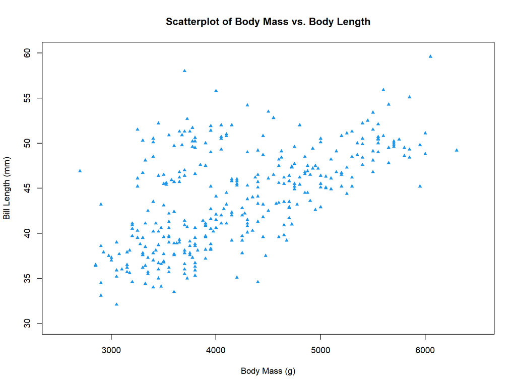

```r
# I use formula notation (data column  on the y axis ~ data column  on the x axis, data = dataset)

# The "col" argument is used to specify the point color. In this case, 4 means that the color will be blue.

# The "pch" argument is used to specify the point shape. In this case, 17 means that the point shape will be a triangle.

# The "cex" argument is used to specify the point size. In this case, 0.75 means 75% of the default size.

# The "main" argument is used to enter the title of the scatterplot and must be written between quotation marks.

# The "xlab" argument is used to enter the name of the x-axis and must be written between quotation marks.

# The "ylab" argument is used to enter the name of the y-axis and must be written between quotation marks.

# The "xlim" argument is used to enter the limits of the x-axis and must be entered as a vector: c(lower limit, upper limit)

# The "ylim" argument is used to enter the limits of the y-axis and must be entered as a vector: c(lower limit, upper limit)

plot(bill_length_mm ~ body_mass_g,
     data = penguins,
     col = 4,
     pch = 17,
     cex = 0.75,
     main = "Scatterplot of Body Mass vs. Body Length",
     xlab = "Body Mass (g)",
     ylab = "Bill Length (mm)",
     xlim = c(2500, 6500),
     ylim = c(30, 60)
)
```

## `hist()`

I can use `hist()` to create histograms.

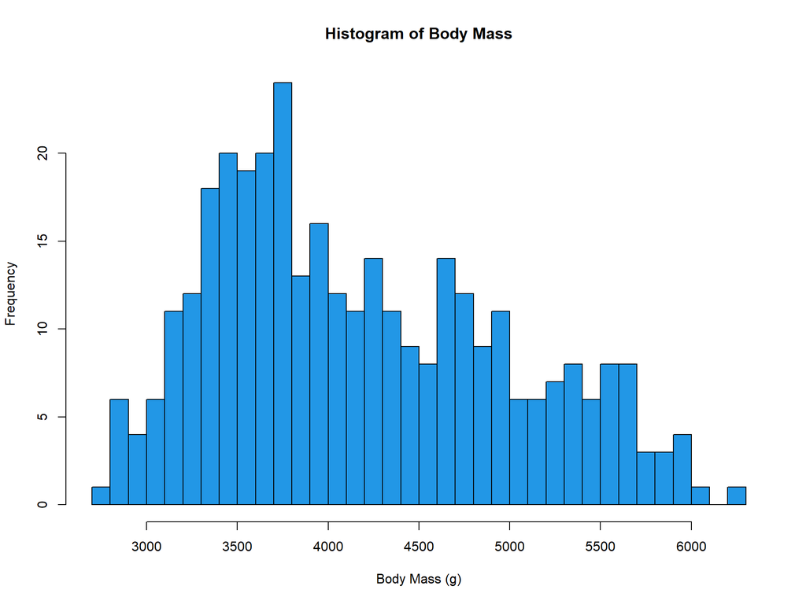

```r
# I use formula notation (data column  on the y axis ~ data column  on the x axis, data = dataset)

# The "col" argument is used to specify the color of the bars. In this case, 4 means that the color will be blue.

# The "main" argument is used to enter the title of the scatterplot and must be written between quotation marks.

# The "xlab" argument is used to enter the name of the x-axis and must be written between quotation marks.

# The name of the y axis is "Frequency" by default

# The "breaks" arguments is used to set the number of breakpoints. A vector also can be entered, one that specifies the breakpoints.

hist(penguins$body_mass_g,
     col = 4,
     main = "Histogram of Body Mass",
     xlab = "Body Mass (g)",
     breaks = 35
     )
```

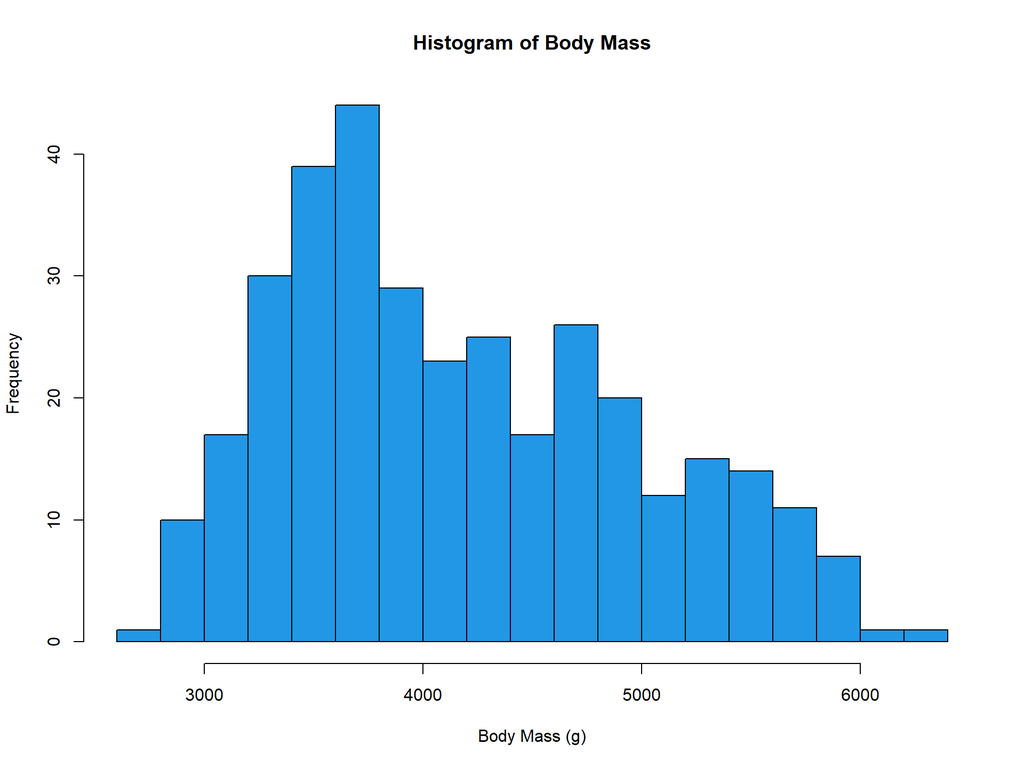

```r
hist(penguins$body_mass_g,
     col = 4,
     main = "Histogram of Body Mass",
     xlab = "Body Mass (g)",
     breaks = c(2600,2800,3000,3200,3400,3600,3800,4000,4200,4400,4600,4800,5000,5200,5400,5600,5800,6000,6200,6400)
     )
```

## `boxplot()`

I can use `boxplot()` to create boxplots.

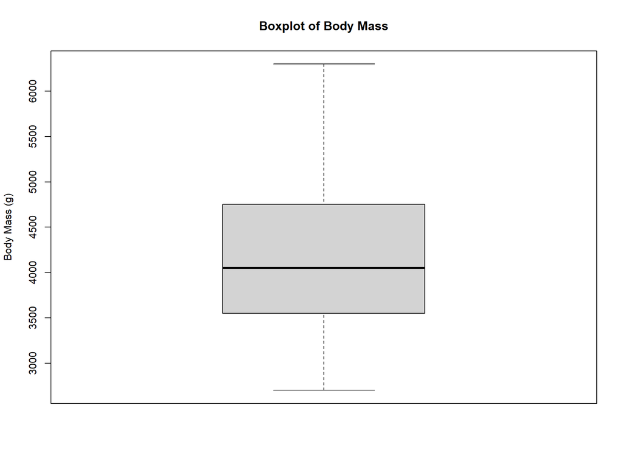

```r
# I use formula notation (data  on the y axis ~ categorical variable  on the x axis, data = dataset)

# The "main" argument is used to enter the title of the scatterplot and must be written between quotation marks.

# The "xlab" argument is used to enter the name of the x-axis and must be written between quotation marks.

# The "ylab" argument is used to enter the name of the y-axis and must be written between quotation marks.


boxplot(penguins$body_mass_g,
        main = "Boxplot of Body Mass",
        ylab = "Body Mass (g)"
        )
```

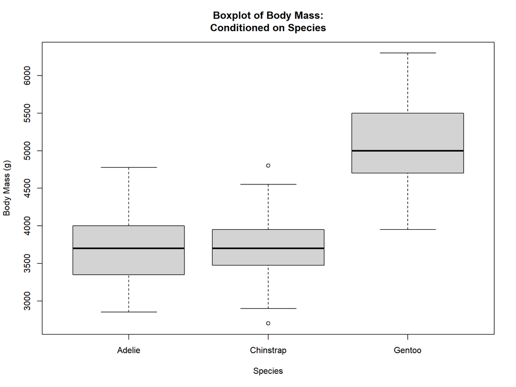

```r
boxplot(body_mass_g ~ species,
        data = penguins,
        main = "Boxplot of Body Mass:
Conditioned on Species",
        xlab = "Species",
        ylab = "Body Mass (g)"
        )
```

## `par()`

I can uses `par()` to combine multiple plots into one overall graph

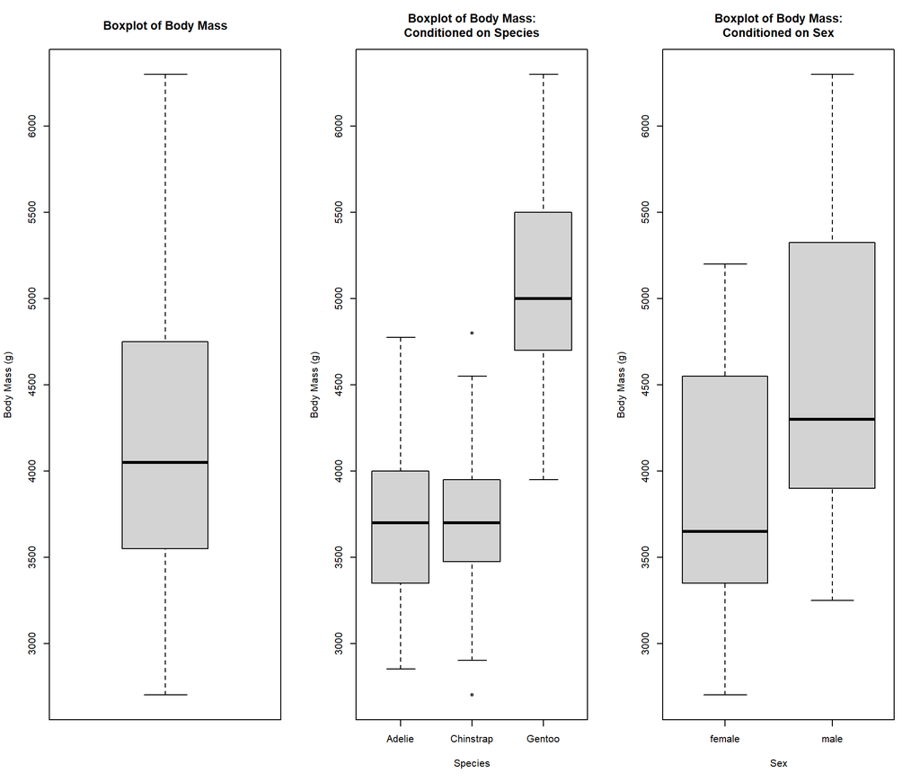

```r
# The argument "mfrow" allows us to put a vector that indicates how many rows and how many columns we want in the graph mfrow=c( number of rows, number of columns). It also indicates that the plots will fill in the graph by the row.

# For example, we can make a graph of 1 row and 3 columns, that contains 3 boxplots.

par(mfrow = c(1,3))

boxplot(penguins$body_mass_g,
        main = "Boxplot of Body Mass",
        ylab = "Body Mass (g)"
        )

boxplot(body_mass_g ~ species,
        data = penguins,
        main = "Boxplot of Body Mass:
Conditioned on Species",
        xlab = "Species",
        ylab = "Body Mass (g)"
        )

boxplot(body_mass_g ~ sex,
        data = penguins,
        main = "Boxplot of Body Mass:
Conditioned on Sex",
        xlab = "Sex",
        ylab = "Body Mass (g)"
        )
```

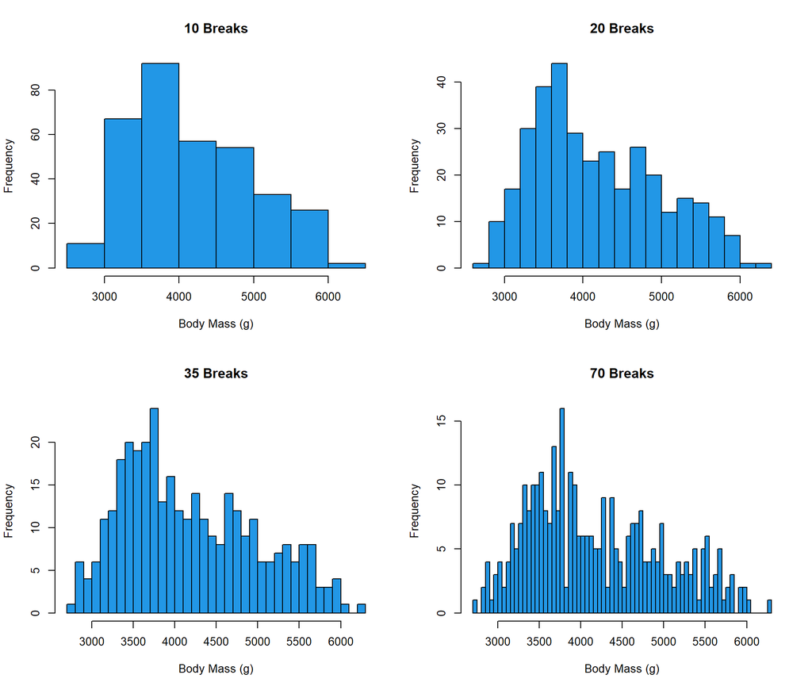

```r
# Also, we can make a graph of 2 rows and 2 columns, that contains 4 histograms.

par(mfrow = c(2,2))

hist(penguins$body_mass_g,
     col = 4,
     main = "10 Breaks",
     xlab = "Body Mass (g)",
     breaks = 10
     )

hist(penguins$body_mass_g,
     col = 4,
     main = "20 Breaks",
     xlab = "Body Mass (g)",
     breaks = 20
     )

hist(penguins$body_mass_g,
     col = 4,
     main = "35 Breaks",
     xlab = "Body Mass (g)",
     breaks = 35
     )

hist(penguins$body_mass_g,
     col = 4,
     main = "70 Breaks",
     xlab = "Body Mass (g)",
     breaks = 70
     )
```

# Functions 4: Distribution Functions

## `dnorm()`

The function `dnorm()` indicates the probability of observing a measurement with a specific value in a normal distribution, given a mean and a standard deviation.

```r
# The first argument (x) must be the specific value of which I want to know the probability of being observed in a normal distribution. The second argument is the mean of this normal distribution and the third argument is its standard deviation.

dnorm(52, mean = 47, sd = 3.4)
```

```
## [1] 0.03979441
```

```r
# The closer the specific value is to the mean, the greater the probability of being observed will be.

dnorm(51, mean = 47, sd = 3.4)
```

```
## [1] 0.05873289
```

```r
dnorm(49, mean = 47, sd = 3.4)
```

```
## [1] 0.09869467
```

## `pnorm()`

The function `pnorm()` indicates the cumulative probability of observing a measurement up to a specific value in a normal distribution, given a mean and a standard deviation.

```r
# The first argument (q) must be the value until which I want to know the cumulative probability of measurements that have been observed in a normal distribution. The second argument is the mean of this normal distribution and the third argument is its standard deviation.

# Basically, we are getting the probability of the measurement being less than the value written in q.

pnorm(52, mean = 47, sd = 3.4)
```

```
## [1] 0.9292987
```

```r
# If we want to know the probability of the measurement being greater than the value written in q, we should subtract our function from 1

1 - pnorm(52, mean = 47, sd = 3.4)
```

```
## [1] 0.07070125
```

## `qnorm()`

The function `qnorm()` indicates the value up to which a stated probability has been accumulated in a normal distribution, given a mean and a standard deviation. It is the inverse of the `pnorm()`

```r
# The first argument (p) must be the cumulative probability of observing a value (a value that we do not know yet) in a normal distribution. The second argument is the mean of this normal distribution and the third argument is its standard deviation.

# Let's try the cumulative probability that we got in the previous function with a value of 52: 0.9292987

qnorm(0.9292987, mean = 47, sd = 3.4)
```

```
## [1] 52
```

## `dbinom()`

The function `dbinom()` gives us the probability of getting a certain number of successes (x) in a certain number of trials (size) where the probability of success on each trial is fixed (prob).

```r
# The first argument (x) must be the number of successes of which I want to know the probability in a binomial distribution. The second argument is the number of trials (size) and the third argument is the fixed probability of success of each trial.

# The probability of getting 35 successes with 100 trials and a probability of success for each trial of 0.4

dbinom(35, size = 100, prob = 0.4)
```

```
## [1] 0.04913282
```

```r
# The probability of getting 47 successes with 100 trials and a probability of success for each trial of 0.4

dbinom(47, size = 100, prob = 0.4)
```

```
## [1] 0.02919091
```

```r
# The probability of getting 28 successes with 100 trials and a probability of success for each trial of 0.4

dbinom(28, size = 100, prob = 0.4)
```

```
## [1] 0.003832099
```

## `pbinom()`

The function `pbinom()` gives us the value of the cumulative density function of the binomial distribution given a specified variable q, number of trials (size) and probability of success on each trial (prob).

```r
# The first argument (q) must be the value until which I want to know the cumulative probability of measurements that have been observed in a binomial distribution. The second argument is the number of trials (size) and the third argument is the fixed probability of success of each trial.

# Basically, we are getting the probability of the measurement being less than the value written in q.

pbinom(47, size = 100, prob = 0.4)
```

```
## [1] 0.9362108
```

```r
# If we want to know the probability of the measurement being greater than the value written in q, we should subtract our function from 1

1 - pbinom(47, size = 100, prob = 0.4)
```

```
## [1] 0.06378918
```

## `qbinom()`

```r
# The first argument (p) must be the cumulative probability of observing a value (a value that we do not know yet) in a binomial distribution. The second argument is the number of trials (size) and the third argument is the fixed probability of success of each trial.

# Let's try the cumulative probability that we got in the previous function with a value of 47: 0.9362108

qbinom(0.9362108, size = 100, prob = 0.4)
```

```
## [1] 47
```

# Functions 5: Other Functions

## `subset()`

The `subset()` function is a way to select a group of variables depending on their characteristics.

```r
# Using the penguins data set (it is the first argument), if we want to analyze only male penguins, we should write in the second argument the name of the column (sex), the symbol == and the characteristic that we wish to extract: "male". Since it is a variable of character type, it should be between quotation marks.

malepenguins = subset(penguins, sex == "male")

# We check this new object malepenguins with the summary function, that provides information. In the category of sex, there should be 0 female individuals.

summary(malepenguins)
```

```
##       species         island   bill_length_mm  bill_depth_mm
##  Adelie   :73   Biscoe   :83   Min.   :34.60   Min.   :14.10
##  Chinstrap:34   Dream    :62   1st Qu.:40.98   1st Qu.:16.07
##  Gentoo   :61   Torgersen:23   Median :46.80   Median :18.45
##                                Mean   :45.85   Mean   :17.89
##                                3rd Qu.:50.33   3rd Qu.:19.25
##                                Max.   :59.60   Max.   :21.50
##  flipper_length_mm  body_mass_g       sex           year
##  Min.   :178.0     Min.   :3250   female:  0   Min.   :2007
##  1st Qu.:193.0     1st Qu.:3900   male  :168   1st Qu.:2007
##  Median :200.5     Median :4300                Median :2008
##  Mean   :204.5     Mean   :4546                Mean   :2008
##  3rd Qu.:219.0     3rd Qu.:5312                3rd Qu.:2009
##  Max.   :231.0     Max.   :6300                Max.   :2009
```

```r
# For the same data set, now we only need the penguins whose weight is heavier than 4700 g. The first argument is the same. In the second argument, we write the name of the column (body_mass_g), the symbol >= and 4700. Since it is a variable of numerical type, no quotation marks are needed.

heavypenguins = subset(penguins, body_mass_g >= 4700)

# We check this new object heavypenguins with the summary function, that provides information. In the category of body_mass_g, the minimum value should be 4700.

summary(heavypenguins)
```

```
##       species         island   bill_length_mm  bill_depth_mm
##  Adelie   : 3   Biscoe   :97   Min.   :41.00   Min.   :13.10
##  Chinstrap: 1   Dream    : 1   1st Qu.:45.95   1st Qu.:14.60
##  Gentoo   :95   Torgersen: 1   Median :48.10   Median :15.30
##                                Mean   :48.04   Mean   :15.42
##                                3rd Qu.:50.00   3rd Qu.:16.00
##                                Max.   :59.60   Max.   :20.70
##  flipper_length_mm  body_mass_g       sex          year
##  Min.   :196.0     Min.   :4700   female:32   Min.   :2007
##  1st Qu.:215.0     1st Qu.:4888   male  :65   1st Qu.:2008
##  Median :218.0     Median :5200   NA's  : 2   Median :2008
##  Mean   :218.3     Mean   :5247               Mean   :2008
##  3rd Qu.:222.0     3rd Qu.:5550               3rd Qu.:2009
##  Max.   :231.0     Max.   :6300               Max.   :2009
```

```r
# Finally, we want to analyze the Adelie and the Chinstrap penguins, excluding the ones from the Gentoo species. The first argument is the same. In the second argument, we write the name of the column (species), the symbol != and "Gentoo". Since it is a variable of character type, it should be between quotation marks.

adeliechinstrap = subset(penguins, species != "Gentoo")

# We check this new object adeliechinstrap with the summary function, that provides information. In the category of species, there should be 0 Gentoo individuals.

summary(adeliechinstrap)
```

```
##       species          island    bill_length_mm  bill_depth_mm
##  Adelie   :152   Biscoe   : 44   Min.   :32.10   Min.   :15.50
##  Chinstrap: 68   Dream    :124   1st Qu.:37.75   1st Qu.:17.50
##  Gentoo   :  0   Torgersen: 52   Median :40.60   Median :18.40
##                                  Mean   :41.91   Mean   :18.37
##                                  3rd Qu.:45.95   3rd Qu.:19.10
##                                  Max.   :58.00   Max.   :21.50
##                                  NA's   :1       NA's   :1
##  flipper_length_mm  body_mass_g       sex           year
##  Min.   :172.0     Min.   :2700   female:107   Min.   :2007
##  1st Qu.:187.0     1st Qu.:3400   male  :107   1st Qu.:2007
##  Median :191.0     Median :3700   NA's  :  6   Median :2008
##  Mean   :191.8     Mean   :3711                Mean   :2008
##  3rd Qu.:196.0     3rd Qu.:3988                3rd Qu.:2009
##  Max.   :212.0     Max.   :4800                Max.   :2009
##  NA's   :1         NA's   :1
```

## `library() and require()`

Both the `library()` function and the `require()` function are used to load packages that have been previously installed in R. However, there are some differences: the `library()` function loads the packages whether they are already loaded or not and gives an error message display if the desired package cannot be loaded; the `require()` function does not load the package again if it already loaded and if one package cannot be found it does not show an error, but just a warning message.

```r
# We will try to load the "here" package that will be needed later to read a file that is located in one of the subfolders of the main folder that we are working in.

# First, we try the `library()` function

library(here)

# Then, we try the `require()` function

require(here)
```

## `read.csv()`

The `read.csv()` function is used to read CSV (comma-separated values) files, which are very commonly used in Excel.

```r
# We will read the "delomys.csv" file that will be necessary for the second part of the final project. This file is not located in the main folder where our environment is located, but in one of its subfolders. This is why we will need to use the function "here" in the argument of read.csv(). Inside here(), there will be two arguments: in the first one we will write the name of the subfolder that contains the file and in the second one we will write the name of the file. Both arguments need to be between quotation marks.

# We also will save the read file into an object called "delomys" so we can use it when we need it in the next part of the project.

delomys = read.csv(here("data", "delomys.csv"))

# To see if the file has been rightly read, we will apply the summary() function to the delomys object. It should provide information about the elements contained in the object.

summary(delomys)
```

```
##        X            genus             binomial           body_mass
##  Min.   :27526   Length:1585        Length:1585        Min.   :  5.00
##  1st Qu.:27950   Class :character   Class :character   1st Qu.: 35.00
##  Median :28348   Mode  :character   Mode  :character   Median : 43.00
##  Mean   :28371                                         Mean   : 44.06
##  3rd Qu.:28790                                         3rd Qu.: 54.00
##  Max.   :35552                                         Max.   :105.00
##   body_length        age                sex              longitude
##  Min.   : 49.0   Length:1585        Length:1585        Min.   :-49681671
##  1st Qu.:106.0   Class :character   Class :character   1st Qu.:      -50
##  Median :116.0   Mode  :character   Mode  :character   Median :      -50
##  Mean   :114.7                                         Mean   :   -62739
##  3rd Qu.:124.0                                         3rd Qu.:      -47
##  Max.   :265.0                                         Max.   :      -41
##     latitude            status
##  Min.   :-22383667   Length:1585
##  1st Qu.:      -29   Class :character
##  Median :      -29   Mode  :character
##  Mean   :   -28272
##  3rd Qu.:      -24
##  Max.   :      -20
```

```r
# Also, we will use the head() function with the delomys object to see the first elements of this object.

head(delomys)
```

```
##       X   genus         binomial body_mass body_length   age    sex longitude
## 1 27526 Delomys Delomys dorsalis      50.5         259 adult female -48.22950
## 2 27528 Delomys Delomys dorsalis      79.0         223 adult female -48.22950
## 3 27529 Delomys Delomys dorsalis      57.0         206 adult female -48.22950
## 4 27530 Delomys Delomys dorsalis      71.0         229 adult   male -48.22950
## 5 27533 Delomys Delomys dorsalis      56.0         105 adult   male -50.39215
## 6 27534 Delomys Delomys dorsalis      50.0         118 adult   male -50.39215
##    latitude status
## 1 -24.20256  alive
## 2 -24.20256  alive
## 3 -24.20256  alive
## 4 -24.20256  alive
## 5 -29.40807  alive
## 6 -29.40807   dead
```

# Part 2: Data Anaylsis

## Data Exploration

### Numerical Exploration

```r
# Use summary() on the body mass and body length data columns in the Delomys data set to display summary statistics.

summary(delomys)
```

```
##        X            genus             binomial           body_mass
##  Min.   :27526   Length:1585        Length:1585        Min.   :  5.00
##  1st Qu.:27950   Class :character   Class :character   1st Qu.: 35.00
##  Median :28348   Mode  :character   Mode  :character   Median : 43.00
##  Mean   :28371                                         Mean   : 44.06
##  3rd Qu.:28790                                         3rd Qu.: 54.00
##  Max.   :35552                                         Max.   :105.00
##   body_length        age                sex              longitude
##  Min.   : 49.0   Length:1585        Length:1585        Min.   :-49681671
##  1st Qu.:106.0   Class :character   Class :character   1st Qu.:      -50
##  Median :116.0   Mode  :character   Mode  :character   Median :      -50
##  Mean   :114.7                                         Mean   :   -62739
##  3rd Qu.:124.0                                         3rd Qu.:      -47
##  Max.   :265.0                                         Max.   :      -41
##     latitude            status
##  Min.   :-22383667   Length:1585
##  1st Qu.:      -29   Class :character
##  Median :      -29   Mode  :character
##  Mean   :   -28272
##  3rd Qu.:      -24
##  Max.   :      -20
```

```r
# Perform a test of normality on the body mass and length columns. You can use shapiro.test()

shapiro.test(delomys$body_mass)
```

```
##
##  Shapiro-Wilk normality test
##
## data:  delomys$body_mass
## W = 0.99506, p-value = 4.33e-05
```

```r
shapiro.test(delomys$body_length)
```

```
##
##  Shapiro-Wilk normality test
##
## data:  delomys$body_length
## W = 0.87609, p-value < 2.2e-16
```

### Graphical Exploration

Using code chunks, create the following plots.

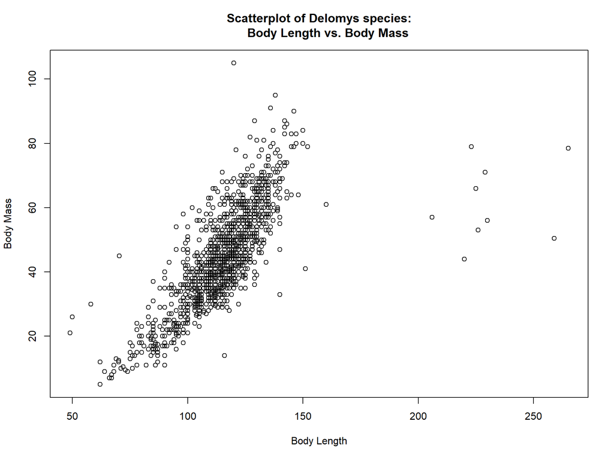

```r
# A scatterplot of body mass and body length

plot(body_mass ~ body_length,
     data = delomys,
     main = "Scatterplot of Delomys species:
     Body Length vs. Body Mass",
     xlab = "Body Length",
     ylab = "Body Mass")
```

**Qualitatively describe the relationship between body mass and length. Does the relationship seem linear, curved, nonexistent?**

The relationship seems to be linear although there are some larger body length values (over 200) for average body mass values. However, we do see a linear pattern for most of the values.

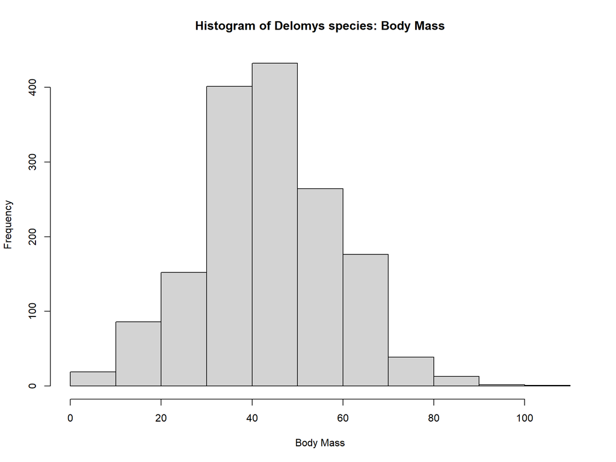

```r
# A histogram of body mass

hist(delomys$body_mass,
     main = "Histogram of Delomys species: Body Mass",
     xlab = "Body Mass")
```

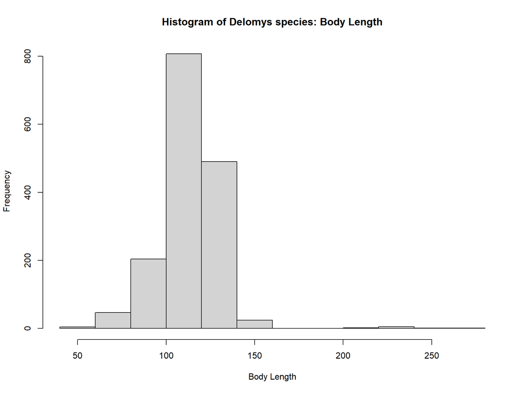

```r
# A histogram of body length

hist(delomys$body_length,
     main = "Histogram of Delomys species: Body Length",
     xlab = "Body Length")
```

**Qualitatively describe the shapes of the histograms. Do the data appear normally-distributed? Explain why or why not.**

The Histogram of Delomys species: Body Mass does have a very normal pattern, since most of the values are concentrated in the center of the distribution and the amount of values decrease in both tails.

As for the Histogram of Delomys species: Body Length, we can see an approximate normal pattern because most values are concentrated in what seems to be the center of the distribution. However, it is not as clearly defined as the previous histogram was, since in the tail located in the right part of the distribution there are ranges with no values at all (160-180, 180-200), but most extreme ranges (200-220, 220-240) do present values, although they are not many.

**Using both the histograms and normality tests, do you think the (unconditioned) body masses and body length are normally-distributed? Contrast your visual assessment of normality to the results of the numerical normality tests.**

The p-value obtained by the Shapiro test for the body mass values is 4.33e-05 and the p-value obtained by the Shapiro test for the body length values is 2.2e-16. Both are very small p-values, that would let us reject the null hypothesis of the values, both for body mass and body length (values being normally distributed). However, there is a conflict between these values and the graphical interpretation, because in the histograms we can see normal patterns, although the normal pattern is more clearly defined for the histogram of body mass than for the histogram of body length. Since there is a conflict, I cannot assure that the body masses and body lengths are normally-distributed, but I think that the data in the graphical exploration in this case is normal enough to assume that the values can be normally distributed.

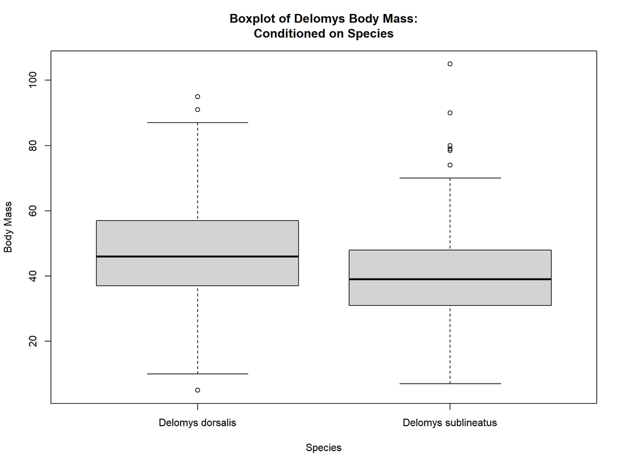

```r
# A conditional boxplot of body mass, conditioned on species

boxplot(body_mass ~ binomial,
        data = delomys,
        main = "Boxplot of Delomys Body Mass:
Conditioned on Species",
        xlab = "Species",
        ylab = "Body Mass")
```

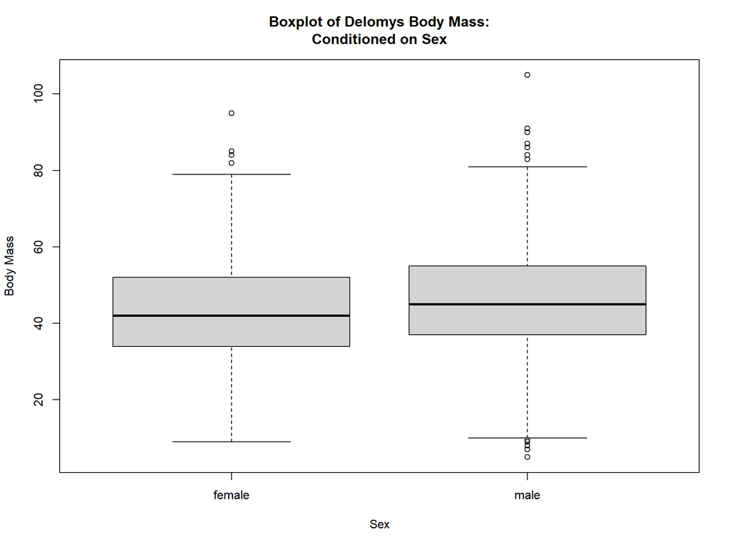

```r
# A conditional boxplot of body mass, conditioned on sex

boxplot(body_mass ~ sex,
        data = delomys,
        main = "Boxplot of Delomys Body Mass:
Conditioned on Sex",
        xlab = "Sex",
        ylab = "Body Mass")
```

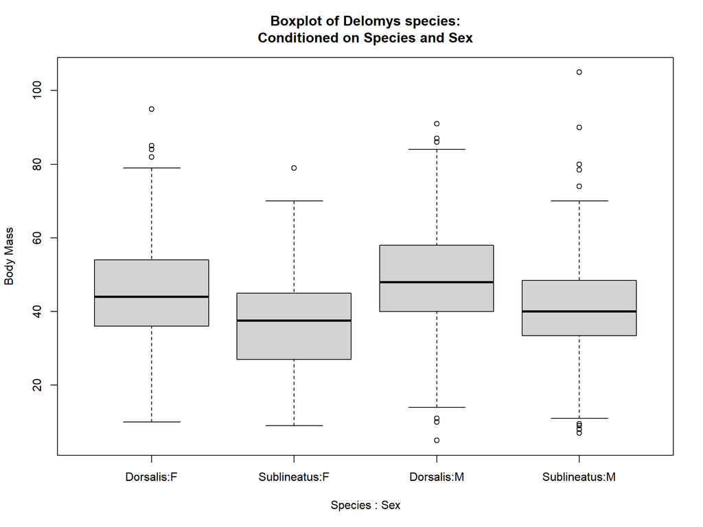

```r
# A conditional boxplot of body mass,  conditioned on both species and sex

boxplot(body_mass ~ binomial*sex,
        data = delomys,
        main = "Boxplot of Delomys species:
Conditioned on Species and Sex",
        xlab = "Species : Sex",
        ylab = "Body Mass",
        names = c("Dorsalis:F", "Sublineatus:F", "Dorsalis:M", "Sublineatus:M"))
```

**Examine the conditional boxplots. Describe any graphical evidence you see for body mass differences based on species and/or sex.**

In the boxplot conditioned on species, we can appreciate that the Delomys dorsalis species seems to have heavier body masses than the Delomys sublineatus species.

As for the boxplot conditioned on sex, we can see that male individuals seem to have heavier body masses than female individuals in the distribution.

Finally, in the boxplot conditioned both on species and sex we can see the same pattern repeated, because if we compare between species of the same sex, we notice that the Delomys dorsalis individuals seem to be heavier in both cases. Also, if we compare between sexes of the same species, the boxplots show that the male individuals seem to be heavier than the female individuals.

## Model Building

We know that the normality assumption applies to the residual values after we fit a model.

Using a code chunk, fit 5 models using lm():

```r
# Model 1: simple linear regression body_length ~ body_mass

fit1 = lm(body_length ~ body_mass, data = delomys)

fit1
```

```
##
## Call:
## lm(formula = body_length ~ body_mass, data = delomys)
##
## Coefficients:
## (Intercept)    body_mass
##     76.1247       0.8755
```

```r
# Model 2: 1-way ANOVA body_mass ~ sex

fit2 = lm(body_mass ~ sex, data = delomys)

fit2
```

```
##
## Call:
## lm(formula = body_mass ~ sex, data = delomys)
##
## Coefficients:
## (Intercept)      sexmale
##      42.711        2.784
```

```r
# Model 3: 1-way ANOVA body_mass ~ binomial

fit3 = lm(body_mass ~ binomial, data = delomys)

fit3
```

```
##
## Call:
## lm(formula = body_mass ~ binomial, data = delomys)
##
## Coefficients:
##                 (Intercept)  binomialDelomys sublineatus
##                      46.752                       -7.683
```

```r
# Model 4: 2-way additive ANOVA body_mass ~ sex + binomial

fit4 = lm(body_mass ~ sex + binomial, data = delomys)

fit4
```

```
##
## Call:
## lm(formula = body_mass ~ sex + binomial, data = delomys)
##
## Coefficients:
##                 (Intercept)                      sexmale
##                      45.070                        3.795
## binomialDelomys sublineatus
##                      -8.193
```

```r
# Model 5: 2-way factorial ANOVA body_mass ~ sex * binomial

fit5 = lm(body_mass ~ sex * binomial, data = delomys)

fit5
```

```
##
## Call:
## lm(formula = body_mass ~ sex * binomial, data = delomys)
##
## Coefficients:
##                         (Intercept)                              sexmale
##                            45.05546                              3.82809
##         binomialDelomys sublineatus  sexmale:binomialDelomys sublineatus
##                            -8.14174                             -0.09502
```

## Model Diagnostics

Let’s check whether our models fulfill the assumption of normality of the residuals.

First, use a graphical approach: plot histograms of the model residuals.

You can retrieve the model residuals using the residuals() function. For example, I could get the residuals from the first model using residuals(fit1). Use a code chunk to create histograms of the residuals of each of the 5 models.

Next, use shapiro.test() on each model to test the null hypothesis that the residuals are drawn from a normally-distributed population.

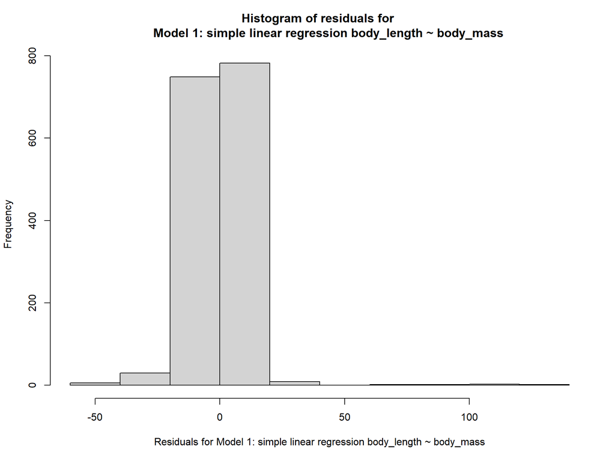

```r
# Model 1: simple linear regression body_length ~ body_mass

hist(residuals(fit1),
     main = "Histogram of residuals for
     Model 1: simple linear regression body_length ~ body_mass",
     xlab = "Residuals for Model 1: simple linear regression body_length ~ body_mass")
```

```r
shapiro.test(residuals(fit1))
```

```
##
##  Shapiro-Wilk normality test
##
## data:  residuals(fit1)
## W = 0.73462, p-value < 2.2e-16
```

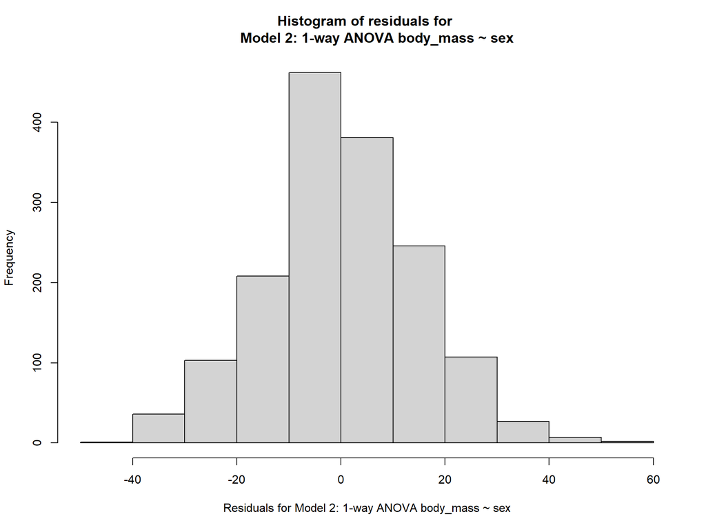

```r
# Model 2: 1-way ANOVA body_mass ~ sex

hist(residuals(fit2),
     main = "Histogram of residuals for
     Model 2: 1-way ANOVA body_mass ~ sex",
     xlab = "Residuals for Model 2: 1-way ANOVA body_mass ~ sex")
```

```r
shapiro.test(residuals(fit2))
```

```
##
##  Shapiro-Wilk normality test
##
## data:  residuals(fit2)
## W = 0.99563, p-value = 0.0001541
```

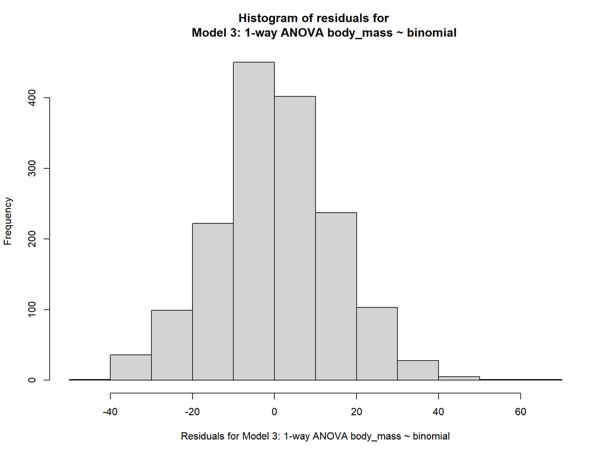

```r
# Model 3: 1-way ANOVA body_mass ~ binomial

hist(residuals(fit3),
     main = "Histogram of residuals for
     Model 3: 1-way ANOVA body_mass ~ binomial",
     xlab = "Residuals for Model 3: 1-way ANOVA body_mass ~ binomial")
```

```r
shapiro.test(residuals(fit3))
```

```
##
##  Shapiro-Wilk normality test
##
## data:  residuals(fit3)
## W = 0.99535, p-value = 8.103e-05
```

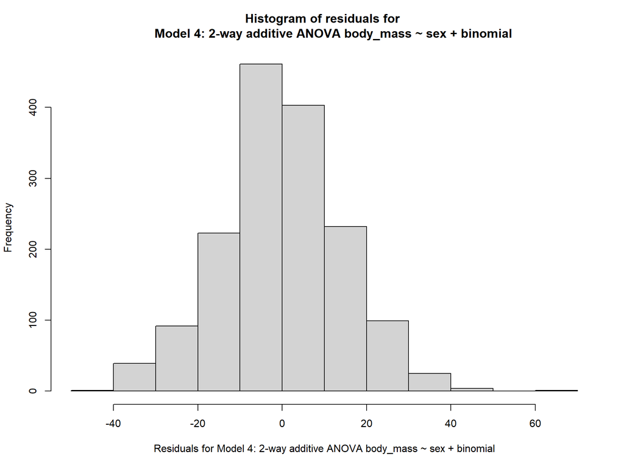

```r
# Model 4: 2-way additive ANOVA body_mass ~ sex + binomial

hist(residuals(fit4),
     main = "Histogram of residuals for
     Model 4: 2-way additive ANOVA body_mass ~ sex + binomial",
     xlab = "Residuals for Model 4: 2-way additive ANOVA body_mass ~ sex + binomial")
```

```r
shapiro.test(residuals(fit4))
```

```
##
##  Shapiro-Wilk normality test
##
## data:  residuals(fit4)
## W = 0.99525, p-value = 6.805e-05
```

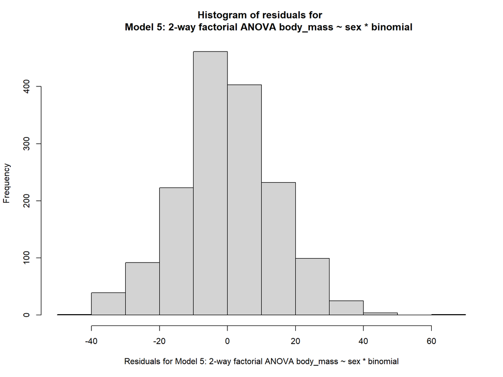

```r
# Model 5: 2-way factorial ANOVA body_mass ~ sex * binomial

hist(residuals(fit5),
     main = "Histogram of residuals for
     Model 5: 2-way factorial ANOVA body_mass ~ sex * binomial",
     xlab = "Residuals for Model 5: 2-way factorial ANOVA body_mass ~ sex * binomial")
```

```r
shapiro.test(residuals(fit5))
```

```
##
##  Shapiro-Wilk normality test
##
## data:  residuals(fit5)
## W = 0.99526, p-value = 6.816e-05
```

**What do you conclude about residual normality based on the numerical and graphical diagnostics?**

The p-value for the first model, the simple linear regression, is by far the smallest one since it is 2.2e-16. None of the p-values are higher than 0.05, but the one for the second model (1-way ANOVA body_mass ~ sex) would be the highest one with 0.0001541. The p-values for the rest of the models are close to the half of this value. Therefore, the numerical exploration would indicate that we can reject the null hypothesis (the values of residuals being normally distributed) for all models.

However, in the graphical exploration, we can see that there are normal patterns for the last four models. For the first model, although there is a peak of amount of residuals and the amount tends to decrease in both tails, the values are very highly concentrated in two ranges and we cannot see a pattern that seems to be normal.

There is a conflict between the numerical and the graphical diagnostics. However, I would say it would be safe to assume a normal distribution for the residuals of the last four models. I would not assume a residual normality for the first model, since both the numerical and graphical explorations do not show normality.

**Are violations of the normality assumption equally severe for all the models?**

No. Violations of the normality distribution are much higher for the first model, both in a graphical and a numerical exploration. The other four models show an approximate normal pattern for the graphical exploration and their p-values are way higher than the one for the first model.

## Model Interpretation

### Body Length

Print the model coefficient table using summary() and answer the following:

```r
# Model 1: simple linear regression body_length ~ body_mass

knitr::kable(coef(summary(fit1)))
```

|  | Estimate | Std. Error | t value | Pr(>\|t\|) |
| --- | --- | --- | --- | --- |
| (Intercept) | 76.1246565 | 0.9158120 | 83.12258 | 0 |
| body_mass | 0.8754988 | 0.0196905 | 44.46298 | 0 |

**What is the magnitude of the mass/length relationship?**

0.8755 mm/g

**What is the expected body length of an an animal that weighs 100g?**

163.67 mm

**What is the expected body length of an animal that weighs 0g?**

76.12 mm

### Body Mass: Model Coefficients

Print the model coefficient tables for each of the body mass model fits.

```r
# Model 2: 1-way ANOVA body_mass ~ sex

knitr::kable(coef(summary(fit2)))
```

|  | Estimate | Std. Error | t value | Pr(>\|t\|) |
| --- | --- | --- | --- | --- |
| (Intercept) | 42.711465 | 0.5288929 | 80.756355 | 0.0000000 |
| sexmale | 2.784133 | 0.7456117 | 3.734024 | 0.0001951 |

```r
# Model 3: 1-way ANOVA body_mass ~ binomial

knitr::kable(coef(summary(fit3)))
```

|  | Estimate | Std. Error | t value | Pr(>\|t\|) |
| --- | --- | --- | --- | --- |
| (Intercept) | 46.752427 | 0.4499933 | 103.89582 | 0 |
| binomialDelomys sublineatus | -7.683058 | 0.7604562 | -10.10322 | 0 |

```r
# Model 4: 2-way additive ANOVA body_mass ~ sex + binomial

knitr::kable(coef(summary(fit4)))
```

|  | Estimate | Std. Error | t value | Pr(>\|t\|) |
| --- | --- | --- | --- | --- |
| (Intercept) | 45.070355 | 0.5556429 | 81.113891 | 0e+00 |
| sexmale | 3.795395 | 0.7259609 | 5.228099 | 2e-07 |
| binomialDelomys sublineatus | -8.193492 | 0.7609985 | -10.766764 | 0e+00 |

```r
# Model 5: 2-way factorial ANOVA body_mass ~ sex * binomial

knitr::kable(coef(summary(fit5)))
```

|  | Estimate | Std. Error | t value | Pr(>\|t\|) |
| --- | --- | --- | --- | --- |
| (Intercept) | 45.0554562 | 0.6052973 | 74.4352459 | 0.0000000 |
| sexmale | 3.8280908 | 0.8966667 | 4.2692460 | 0.0000208 |
| binomialDelomys sublineatus | -8.1417394 | 1.1281046 | -7.2171847 | 0.0000000 |
| sexmale:binomialDelomys sublineatus | -0.0950187 | 1.5285856 | -0.0621612 | 0.9504424 |

**What is the base level for sex?**

Female.

**What is the base level for binomial?**

Delomys dorsalis.

**Which sex is heavier?**

Male.

**Which species is heavier?**

Delomys dorsalis.

### Body Mass: ANOVA

Print the ANOVA tables for each of the body mass models.

```r
# Model 2: 1-way ANOVA body_mass ~ sex

knitr::kable(anova(fit2))
```

|  | Df | Sum Sq | Mean Sq | F value | Pr(>F) |
| --- | --- | --- | --- | --- | --- |
| sex | 1 | 3061.678 | 3061.6779 | 13.94294 | 0.0001951 |
| Residuals | 1578 | 346507.131 | 219.5863 | NA | NA |

```r
# Model 3: 1-way ANOVA body_mass ~ binomial

knitr::kable(anova(fit3))
```

|  | Df | Sum Sq | Mean Sq | F value | Pr(>F) |
| --- | --- | --- | --- | --- | --- |
| binomial | 1 | 21289.68 | 21289.6805 | 102.0751 | 0 |
| Residuals | 1583 | 330164.45 | 208.5688 | NA | NA |

```r
# Model 4: 2-way additive ANOVA body_mass ~ sex + binomial

knitr::kable(anova(fit4))
```

|  | Df | Sum Sq | Mean Sq | F value | Pr(>F) |
| --- | --- | --- | --- | --- | --- |
| sex | 1 | 3061.678 | 3061.6779 | 14.95838 | 0.0001144 |
| binomial | 1 | 23727.134 | 23727.1342 | 115.92320 | 0.0000000 |
| Residuals | 1577 | 322779.997 | 204.6798 | NA | NA |

```r
# Model 5: 2-way factorial ANOVA body_mass ~ sex * binomial

knitr::kable(anova(fit5))
```

|  | Df | Sum Sq | Mean Sq | F value | Pr(>F) |
| --- | --- | --- | --- | --- | --- |
| sex | 1 | 3.061678e+03 | 3.061678e+03 | 14.948932 | 0.0001150 |
| binomial | 1 | 2.372713e+04 | 2.372713e+04 | 115.849977 | 0.0000000 |
| sex:binomial | 1 | 7.913846e-01 | 7.913846e-01 | 0.003864 | 0.9504424 |
| Residuals | 1576 | 3.227792e+05 | 2.048091e+02 | NA | NA |

**Are sex and species significant predictors for body mass?**

Yes. Both p-values are extremely low (0.0001951 for sex and 0 for species), so, we can reject the null hypothesis of ANOVA (the average value of body mass being the same for all groups). Therefore, both sex and species are significant predictors for body mass.

**Is there a significant interaction?**

No. The p-value for the interaction between sex and species is extremely high (0.9504424), so, we cannot reject the null hypothesis of ANOVA (the average value of body mass being the same for all groups). Therefore, the interaction between sex and species is not significant.

**Does the significance (as measured by p-value) of either of the main effects (sex and species) differ much between the single-predictor models, the additive model, and the interactive model?**

*Sex:*

Single-predictor: 0.0001951

Additive: 0.0001144

Interactive: 0.0001150

*Species:*

Single-predictor:0

Additive: 0

Interactive: 0

So, the answer would be no for both. The significance of sex differs by a very little amount among models and the significance of species does not differ at all among models.

## Model Comparison: Body Mass

You built four different models of body mass. How do you choose the best one?

One option is to choose the model with the lowest AIC. You can calculate AIC using the appropriately named AIC() function.

Create a code chunk that calculates the AIC values for each of the body mass models.

```r
# Model 2: 1-way ANOVA body_mass ~ sex

AIC(fit2)
```

```
## [1] 13006.8
```

```r
# Model 3: 1-way ANOVA body_mass ~ binomial

AIC(fit3)
```

```
## [1] 12966.36
```

```r
# Model 4: 2-way additive ANOVA body_mass ~ sex + binomial

AIC(fit4)
```

```
## [1] 12896.73
```

```r
# Model 5: 2-way factorial ANOVA body_mass ~ sex * binomial

AIC(fit5)
```

```
## [1] 12898.72
```

**Which two models have the lowest AIC?**

Model 4: 12896.73

Model 5: 12898.72

**Which of the two models with lowest AIC scores would you select?**

Model 4: 2-way additive ANOVA body_mass ~ sex + binomial

**Explain your decision based on model fit and the complexity/understanding tradeoff**

I would choose Model 4 not only because it has the lowest AIC value, but also because with the ANOVA analysis that we performed for each model, we could verify that both sex and species are significant predictors for body mass, but the interaction between sex and species is not significant. Therefore, I do not think it would be necessary to include the interaction of Model 5 in the final model.